# Legacy Workflow: CNT Files to Tilia XML

> **Starting a new project?** See the *Counting at the Microscope* vignette (`vignette("counting", package = "pcountr")`) for the primary `count_app()` workflow. This vignette covers the legacy path: reading existing MS-DOS PCount `.CNT` files and converting them through to Tilia XML export.

This vignette walks through the full pcountr workflow from reading legacy PCount `.CNT` files through stratigraphic visualisation and Tilia XML export. Each section corresponds to a stage a palynologist would encounter in practice.

## The Fake Lake dataset

The examples below use **Fake Lake**, a simulated site bundled with pcountr. The pollen assemblages are derived from real counts; depths and ages are fictional. The site consists of 20 samples spanning 0–95 cm (roughly 2,000 cal yr BP) with a standard Lycopodium spike (2 tablets, 9,666 spores per tablet, 1 g sediment per sample).

Fake Lake ships with two things: a folder of `.CNT` files and a pre-filled metadata CSV.

```r
library(pcountr)

cnt_dir   <- system.file("extdata", "fake_lake", package = "pcountr")
meta_path <- system.file("extdata", "fake_lake", "metadata_FL.csv",
                         package = "pcountr")
dic_path  <- system.file("extdata", "fake_lake", "ECG.csv",
                         package = "pcountr")
```

## Part 1: Reading CNT files

### Loading the site

`read_site()` discovers every `.CNT` (and `.yaml`) file in a folder, parses them in parallel, and returns a `pollen_site` object with all samples ordered by depth. Pass the metadata CSV to attach depths, ages, and spike parameters in one step.

```r
site <- read_site(cnt_dir, metadata = meta_path, dic = dic_path)
```

```
#> Warning: FL002.CNT: 2 anomaly/anomalies recorded (see attr(x,'anomalies')).
#> Warning: FL004.CNT: 1 anomaly/anomalies recorded (see attr(x,'anomalies')).
#> Warning: FL010.CNT: 1 anomaly/anomalies recorded (see attr(x,'anomalies')).
#> Warning: FL011.CNT: 1 anomaly/anomalies recorded (see attr(x,'anomalies')).
#> Warning: FL016.CNT: 1 anomaly/anomalies recorded (see attr(x,'anomalies')).
#> Warning: FL020.CNT: 1 anomaly/anomalies recorded (see attr(x,'anomalies')).
```

```r
print(site)
```

```
#> <pollen_site> fake_lake
#>   dictionary: 231 taxa (=4, A=73, B=102, F=26, Q=18, X=8)
#>   pollen sum (basic): A+B+F
#>   samples: 20 (depth 0.0-95.0 cm; 0 without depth)
#>   preservation codes: 1=well-preserved, 2=corroded, 3=degraded, 4=crumpled, exine thinned, 5=undefined, 6=crumpled, exine normal, 7=undefined, 8=broken, 9=hidden, 0=half-grain
```

### Inspecting a single sample

Each sample is a `pollen_count` object stored in `site$samples`. The `$meta` list holds all per-sample metadata; `$grains` is a data frame of individual grain records in counting order.

```r
# First sample
s1 <- site$samples[["FL001"]]

# Metadata
cat("Sample:", s1$meta$sample_name, "\n")
```

```
#> Sample: NA
```

```r
cat("Depth: ", s1$meta$depth_top, "–", s1$meta$depth_bottom, "cm\n")
```

```
#> Depth:  0 – 0.25 cm
```

```r
cat("Age:   ", s1$meta$age_top,   "–", s1$meta$age_bottom,   "cal yr BP\n")
```

```
#> Age:    -50 – -45 cal yr BP
```

```r
cat("Spike: ", s1$meta$spike_tablets, "tablets ×",
               s1$meta$spike_density, "spores/tablet\n")
```

```
#> Spike:  2 tablets × 9666 spores/tablet
```

```r
# Quick count summary
m <- count_metrics(s1)
cat("\nBasic pollen sum:  ", m$basic_sum, "\n")
```

```
#>
#> Basic pollen sum:   331.5
```

```r
cat("Spike counted:     ", m$spike, "\n")
```

[output not shown]

```r
cat("Sum/spike ratio:   ", round(m$ratio, 4), "\n")
```

```
#> Sum/spike ratio:    4.7014
```

```r
cat("Concentration:     ", round(m$concentration), "grains/g\n")
```

```
#> Concentration:      90887 grains/g
```

### Checking for anomalies

`read_cnt()` (called internally by `read_site()`) imports every grain permissively and logs any token that doesn’t resolve against the dictionary. Access the anomaly table via the `anomalies` attribute.

```r
anom <- attr(s1, "anomalies")
if (nrow(anom) == 0) {
  cat("No anomalies in FL001.\n")
} else {
  print(anom)
}
```

```
#> No anomalies in FL001.
```

## Part 2: The counting app

`count_app()` launches an interactive Shiny application that replaces the DOS PCount counting loop. It is designed for use at the microscope.

```r
# Not run in vignette — requires an interactive session and Shiny
count_app()
```

**Workflow inside the app:**

1. **Setup screen** — Select a dictionary (`.DIC` or `.csv`), enter spike parameters and sample quantity, set the sample name, title, depth and age, choose a YAML save path, and click *Start Counting*.
2. **Counting** — Type grain tokens (`B1`, `I80`, `A1`) followed by Enter. The app parses each token against the loaded dictionary. Type `.` for a spike grain, `/label/` to mark a traverse, and `[text]` for an inline remark. Unknown or malformed tokens trigger a prominent alert with an audio beep.
3. **Live metrics** — The running ΣP sum, spike count, concentration (grains/g or grains/cm³), and PAR update after every entry. `NA` appears until all required inputs are present.
4. **Mid-count editing** — All metadata fields are editable on the *Sample Info* tab while counting. The save path is locked once counting starts.
5. **Autosave** — The YAML is written after every single entry. *Done / Save* is a confirmation step, not the save trigger. Resume a past count with *Open Existing Count* on the setup screen — grain order, traverses, remarks, and spike total are restored exactly.
6. **New sample** — After finishing a count, *New Sample* carries over instrument metadata and suggests an incremented save path.

Once YAML files have been created by the app, load them with `read_site()` exactly as you would load `.CNT` files. Depths and spike parameters saved during counting are embedded in the YAML, so no separate metadata sheet is needed.

## Part 3: Visualisation

### Building the site matrix

`site_matrix()` converts the loaded site into a list of parallel matrices and vectors suitable for `rioja::strat.plot()`. Taxon names from the dictionary are used as column labels by default.

```r
mat <- site_matrix(site, min_present = 2)

# Dimensions
cat("Samples:", nrow(mat$TaxaPerc), "\n")
```

```
#> Samples: 20
```

```r
cat("Taxa:   ", ncol(mat$TaxaPerc), "\n")
```

```
#> Taxa:    29
```

```r
# Depth and age ranges
cat("Depth range:", range(mat$DepTop), "cm\n")
```

```
#> Depth range: 0 95 cm
```

```r
cat("Age range:  ", range(mat$AgeTop, na.rm = TRUE), "cal yr BP\n")
```

```
#> Age range:   -50 1898 cal yr BP
```

```r
# Top 5 taxa by mean percentage
top5 <- sort(colMeans(mat$TaxaPerc, na.rm = TRUE), decreasing = TRUE)[1:5]
round(top5, 1)
```

```
#>       Betula Alnus rugosa        Picea   Cyperaceae        Salix
#>         42.2         28.4         11.3          5.8          3.8
```

### Stratigraphic diagram

Pass `TaxaPerc` and `DepTop` to `rioja::strat.plot()`. The `y.rev = TRUE` argument places the surface at the top (shallower = younger = higher on the plot), which is standard for stratigraphic diagrams.

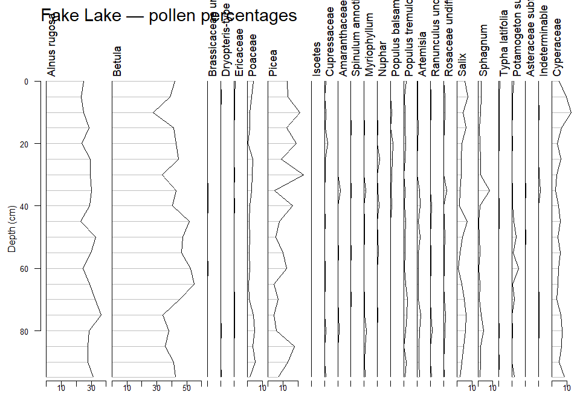

```r
if (requireNamespace("rioja", quietly = TRUE)) {
  # Select taxa present in at least 3 samples for a clean diagram
  keep <- colSums(mat$TaxaPerc > 0) >= 3

  rioja::strat.plot(
    mat$TaxaPerc[, keep],
    yvar        = mat$DepTop,
    y.rev       = TRUE,
    scale.percent = TRUE,
    ylabel      = "Depth (cm)",
    title       = "Fake Lake — pollen percentages"
  )
} else {
  message("Install the rioja package to produce the stratigraphic diagram.")
}
```

[output not shown]

[output cut: 301 more lines]

[output not shown]

[figure not shown]

```r
if (requireNamespace("rioja", quietly = TRUE)) {
  keep <- colSums(mat$TaxaPerc > 0) >= 3

  rioja::strat.plot(
    mat$TaxaPerc[, keep],
    yvar        = mat$DepTop,
    y2var       = mat$AgeTop,
    y.rev       = TRUE,
    scale.percent = TRUE,
    ylabel      = "Depth (cm)",
    y2label     = "Age (cal yr BP)",
    title       = "Fake Lake — pollen percentages"
  )
}
```

### Concentration and accumulation rates

`site_matrix()` also returns per-taxon concentrations (`TaxaConc`) and accumulation rates (`TaxaAccRate`) when all required inputs are present.

```r
# Total pollen concentration per sample (sum across all taxa)
total_conc <- rowSums(mat$TaxaConc, na.rm = TRUE)
data.frame(
  Sample   = rownames(mat$TaxaPerc),
  Depth_cm = mat$DepTop,
  Age_BP   = mat$AgeTop,
  Conc_grains_per_g = round(total_conc)
)
```

```
#>       Sample Depth_cm Age_BP Conc_grains_per_g
#> FL001  FL001        0    -50             90887
#> FL002  FL002        5     52             77553
#> FL003  FL003       10    155             38474
#> FL004  FL004       15    258             90981
#> FL005  FL005       20    360             62970
#> FL006  FL006       25    462             92050
#> FL007  FL007       30    565             35077
#> FL008  FL008       35    668             19004
#> FL009  FL009       40    770             56440
#> FL010  FL010       45    872             75731
#> FL011  FL011       50    975             57233
#> FL012  FL012       55   1078             47303
#> FL013  FL013       60   1180             54746
#> FL014  FL014       65   1282             28716
#> FL015  FL015       70   1385             39933
#> FL016  FL016       75   1488             52048
#> FL017  FL017       80   1590             38035
#> FL018  FL018       85   1692             23404
#> FL019  FL019       90   1795             18883
#> FL020  FL020       95   1898             45928
```

Use `accum_rate()` for a dedicated summary that also validates all required inputs up front and reports every deficiency in a single error message.

```r
ar <- accum_rate(site)
print(ar$data)
```

```
#>    sample depth_top depth_bottom age_top age_bottom deposition_time
#> 1   FL001         0         0.25     -50        -45              20
#> 2   FL002         5         5.25      52         58              24
#> 3   FL003        10        10.25     155        160              20
#> 4   FL004        15        15.25     258        263              20
#> 5   FL005        20        20.25     360        365              20
#> 6   FL006        25        25.25     462        468              24
#> 7   FL007        30        30.25     565        570              20
#> 8   FL008        35        35.25     668        673              20
#> 9   FL009        40        40.25     770        775              20
#> 10  FL010        45        45.25     872        878              24
#> 11  FL011        50        50.25     975        980              20
#> 12  FL012        55        55.25    1078       1083              20
#> 13  FL013        60        60.25    1180       1185              20
#> 14  FL014        65        65.25    1282       1288              24
```

[output cut: 27 more lines]

## Part 4: Export to Tilia XML

`write_tlx()` exports the entire site to a `.tlx` file readable by Tilia and suitable for upload to the Neotoma Paleoecology Database. The output contains four spreadsheet pages (Data, Percents, Concentrations, Accumulation) with nine shared metadata header rows per sample, matching Tilia’s own output format.

```r
tlx_path <- tempfile(fileext = ".tlx")
write_tlx(site, file = tlx_path)

cat("TLX written to:", tlx_path, "\n")
```

```
#> TLX written to: C:\Users\WILLIA~1.NAN\AppData\Local\Temp\RtmpuQ14ld\file45e47a666f82.tlx
```

```r
cat("File size:", file.size(tlx_path), "bytes\n")
```

```
#> File size: 420833 bytes
```

```r
# Peek at the root element to confirm well-formed XML
if (requireNamespace("xml2", quietly = TRUE)) {
  doc  <- xml2::read_xml(tlx_path)
  root <- xml2::xml_name(xml2::xml_root(doc))
  pages <- xml2::xml_find_all(doc, "//SpreadSheet")
  cat("Root element:", root, "\n")
  cat("Pages:", length(pages), "\n")
  cat("Page names:", paste(
    xml2::xml_attr(pages, "name"), collapse = ", "), "\n")
}
```

```
#> Root element: TiliaFile
#> Pages: 4
#> Page names: Data, Percents, Concentrations, Accumulation
```

**After opening the TLX in Tilia:**

- Fill in the *Site* and *Collection Unit* tabs with location, physiography, and coring details.
- Add radiocarbon dates on the *Chronology* tab and run Bchron or Bacon within Tilia to build the age model.
- CONISS is not computed by pcountr — run it from the *Analysis* menu in Tilia or via `rioja::chclust()` before upload.
- Submit to Neotoma through Tilia’s *Neotoma* menu once the dataset is complete.

## Summary of the workflow

```r
library(pcountr)

# 1. Load CNT files and attach metadata
site <- read_site("path/to/cnt/folder",
                  metadata = "metadata.csv")

# 2. Count new samples interactively (saves YAML automatically)
count_app()

# 3. Reload site once new YAMLs are saved (read_site picks up both CNT and YAML)
site <- read_site("path/to/counts")

# 4. Build the site matrix
mat <- site_matrix(site, min_present = 2)

# 5. Stratigraphic diagram
rioja::strat.plot(mat$TaxaPerc, yvar = mat$DepTop, y.rev = TRUE,
                  scale.percent = TRUE)

# 6. Accumulation rates
ar <- accum_rate(site)

# 7. Export to Tilia
write_tlx(site, file = "my_site.tlx")
```